# Análise de Diamantes

Este é o exercício para revisão das de algumas técnicas para explorar 1 variável.

```r
# carrega o pacote ggplot
library(ggplot2)
# carrega o conjunto de dados de diamantes, ele vem junto com o pacote ggplot
data(diamonds)
# visualiza as informações básicas sobre o dataset estudado
?diamonds
```

```
## starting httpd help server ... done
```

```r
# visualizar o nome das variáveis do dataset
names(diamonds)
```

```
##  [1] "carat"   "cut"     "color"   "clarity" "depth"   "table"   "price"
##  [8] "x"       "y"       "z"
```

```r
# visualiza uma tabela com os valores da coluna selecionada
table(diamonds$cut)
```

```
##
##      Fair      Good Very Good   Premium     Ideal
##      1610      4906     12082     13791     21551
```

Podemos perceber no histograma que a distribuição possui uma inclinação positiva.

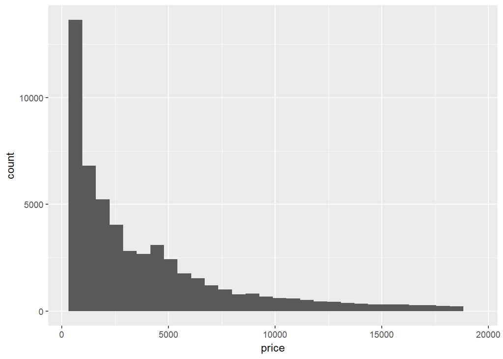

```r
ggplot(aes(x = price), data = diamonds) +
  geom_histogram()
```

Estatísticas básicas dos diamantes

```r
summary(diamonds$price)
```

```
##    Min. 1st Qu.  Median    Mean 3rd Qu.    Max.
##     326     950    2401    3933    5324   18823
```

Contagem de diamantes

```r
#Quantidade de diamantes com preço menor que $500
sum(diamonds$price < 500)
```

```
## [1] 1729
```

```r
#Quantidade de diamantes com preço menor que $500
sum(diamonds$price < 250)
```

```
## [1] 0
```

```r
#Quantidade de diamantes com preço maior ou igual a $15.000
sum(diamonds$price >= 15000)
```

```
## [1] 1656
```

Vamos analisar maior pico encontrado na visualização anterior, para isso, iremos limitar o x-axis:

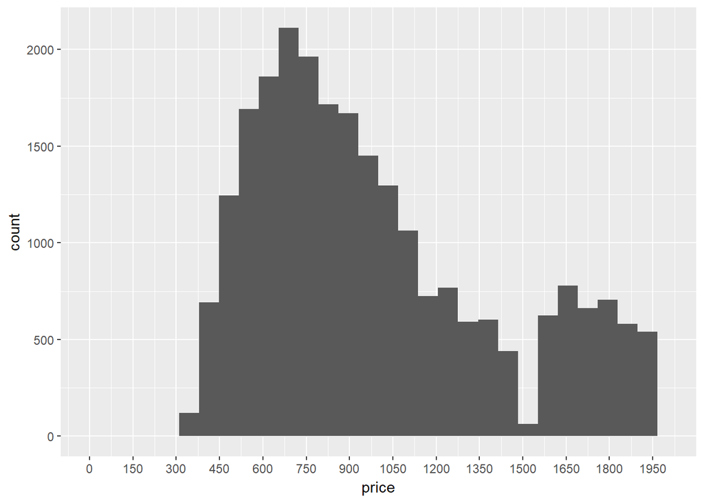

```r
qplot(x = price, data = diamonds) +
  scale_x_continuous(limits = c(0, 2000), breaks = seq(0, 2000, 150))
```

```r
#1º Não existem diamantes com preço de $1500
#2º Percebe-se que para os diamantes que custam menos que $2000, o preço mais comum é em torno de $700
```

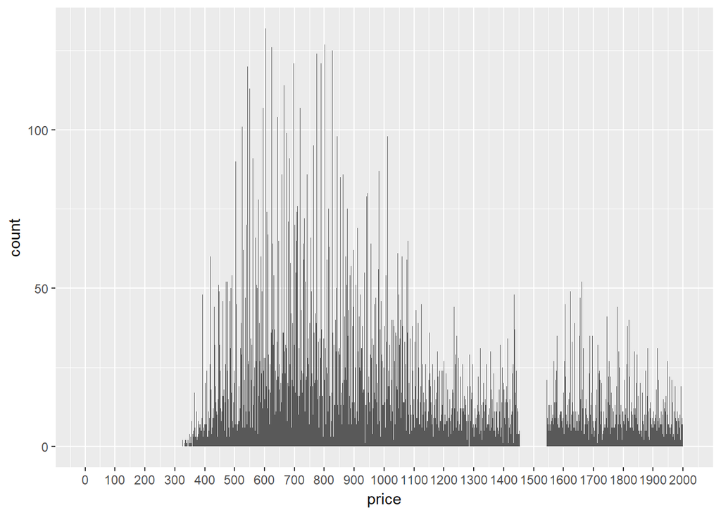

```r
qplot(x = price, data = diamonds, binwidth = 1) +
  scale_x_continuous(limits = c(0, 2000), breaks = seq(0, 2000, 100))
```

Distribuição dos diamantes por corte

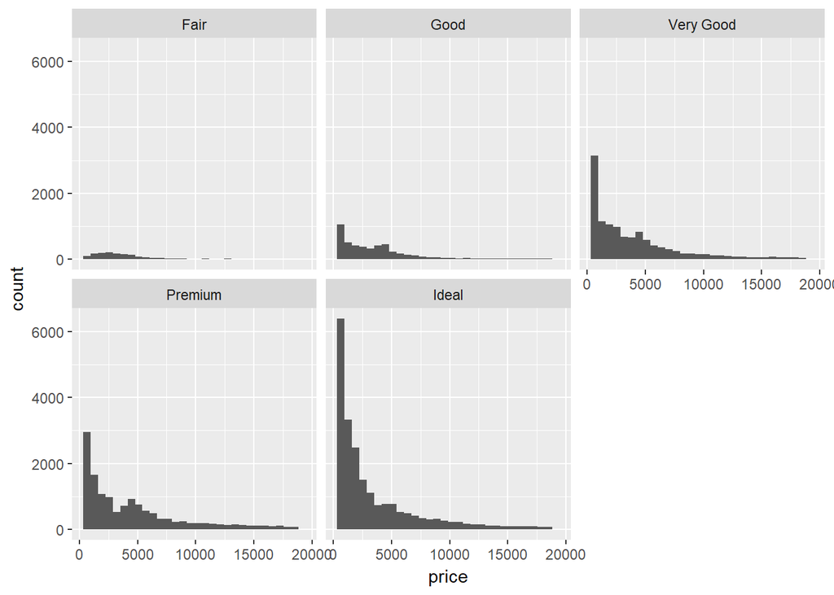

```r
qplot(x = price, data = diamonds) +
  facet_wrap(~cut)
```

A visualização abaixo demonstra estatísticas básicas sobre cutXpreço. Responde algumas perguntas como: - Qual corte tem o menor/maior preço? - Qual corte tem o menor/maior preço médio?

```r
 by(diamonds$price,diamonds$cut,summary)
```

```
## diamonds$cut: Fair
##    Min. 1st Qu.  Median    Mean 3rd Qu.    Max.
##     337    2050    3282    4359    5206   18574
## --------------------------------------------------------
## diamonds$cut: Good
##    Min. 1st Qu.  Median    Mean 3rd Qu.    Max.
##     327    1145    3050    3929    5028   18788
## --------------------------------------------------------
## diamonds$cut: Very Good
##    Min. 1st Qu.  Median    Mean 3rd Qu.    Max.
##     336     912    2648    3982    5373   18818
## --------------------------------------------------------
## diamonds$cut: Premium
##    Min. 1st Qu.  Median    Mean 3rd Qu.    Max.
##     326    1046    3185    4584    6296   18823
## --------------------------------------------------------
## diamonds$cut: Ideal
##    Min. 1st Qu.  Median    Mean 3rd Qu.    Max.
##     326     878    1810    3458    4678   18806
```

No último gráfico, analisamos as estatísticas de resumo para preço de diamante por corte. Se olharmos para a tabela de saída acima, a mediana e os quartis são razoavelmente próximos uns dos outros. Isso significa que as distribuições devem ser um pouco semelhantes, mas os histogramas que criamos não mostram isso.

Os diamantes “Fair” e “Good” parecem ter diferentes distribuições em relação ao melhor corte de diamantes. Parecem um pouco uniformes à esquerda com uma cauda longa a direita.

Normalmente as escalas dos eixos em cada gráficos são fixas, isso está dificultando a visualização dos cortes com menos dados. Para isso, será definido scales =“free” para deixas as scalas independentes.

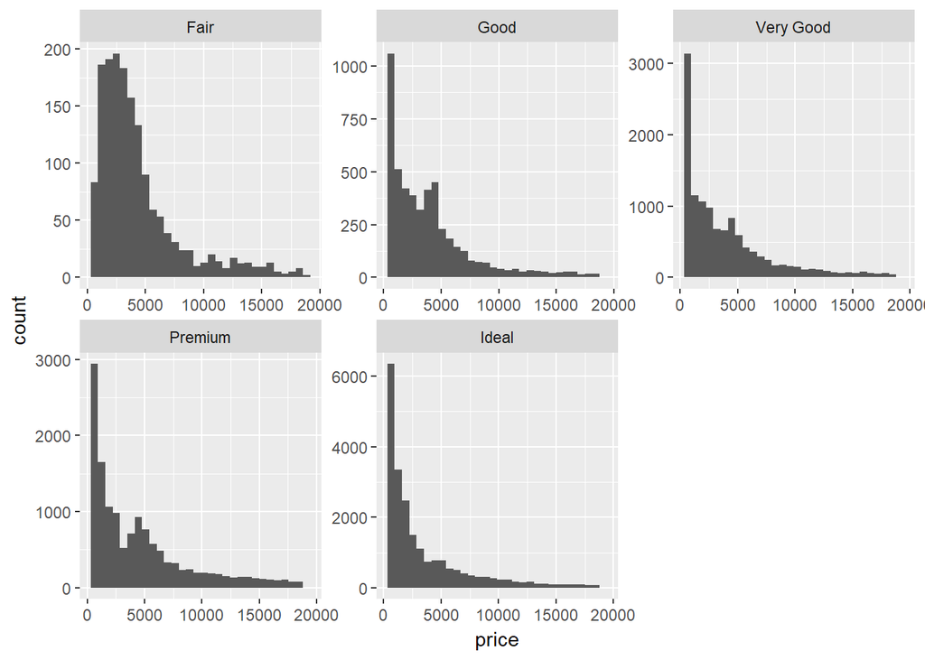

```r
qplot( x = price, data = diamonds) +
facet_wrap(~cut, scales = "free")
```

Criamos um histograma de preço por quilate e facetamos por corte. Foi realizado ajustes para deixar as escalas livres e para aumentar a largura do compartimento com scale_x_log10()

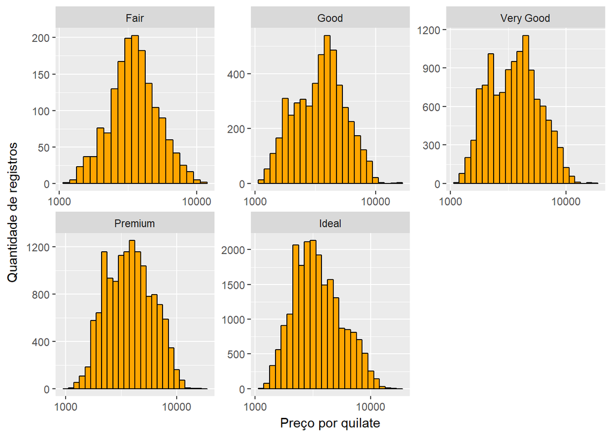

```r
qplot(x = price/carat, data = subset(diamonds, !is.na(cut)),
      binwidth = 0.05, color = I('black'), fill = I('#FFA500'),
      xlab = "Preço por quilate",
      ylab = "Quantidade de registros") +
      facet_wrap(~cut, scales = "free") +
      scale_x_log10()
```

Boxplot de corte por preço

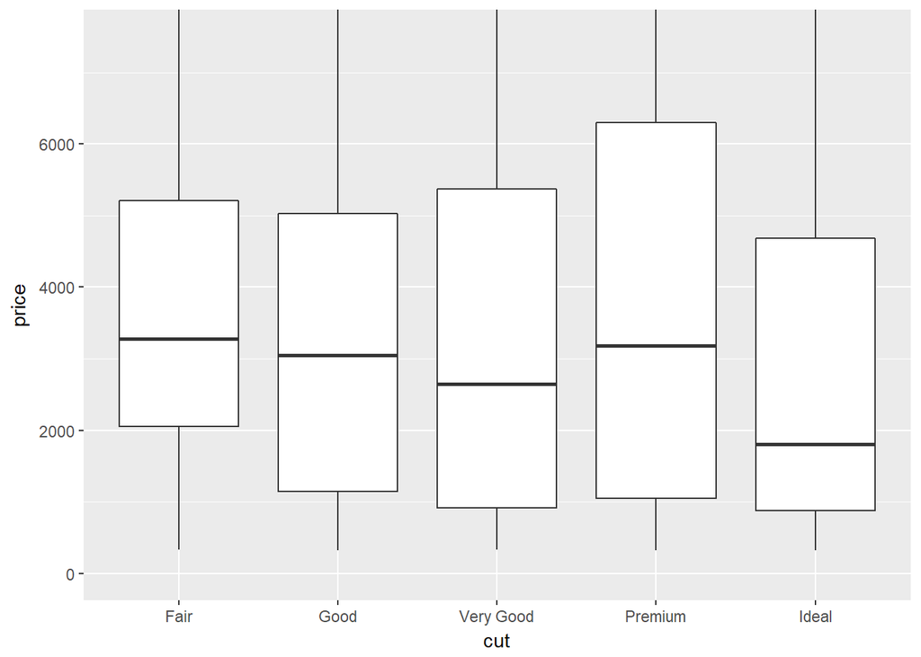

```r
qplot(x = cut, y = price,
      data = diamonds,
      geom = 'boxplot') +
      coord_cartesian(ylim = c(0, 7500))
```

```r
by(diamonds$price,diamonds$cut,summary)
```

```
## diamonds$cut: Fair
##    Min. 1st Qu.  Median    Mean 3rd Qu.    Max.
##     337    2050    3282    4359    5206   18574
## --------------------------------------------------------
## diamonds$cut: Good
##    Min. 1st Qu.  Median    Mean 3rd Qu.    Max.
##     327    1145    3050    3929    5028   18788
## --------------------------------------------------------
## diamonds$cut: Very Good
##    Min. 1st Qu.  Median    Mean 3rd Qu.    Max.
##     336     912    2648    3982    5373   18818
## --------------------------------------------------------
## diamonds$cut: Premium
##    Min. 1st Qu.  Median    Mean 3rd Qu.    Max.
##     326    1046    3185    4584    6296   18823
## --------------------------------------------------------
## diamonds$cut: Ideal
##    Min. 1st Qu.  Median    Mean 3rd Qu.    Max.
##     326     878    1810    3458    4678   18806
```

Com o a visualização abaixo, temos a impressão que o diamante com clareza de menor qualidade(I1), está dando melhores retornos que o diamante de melhor qualidade(IF).

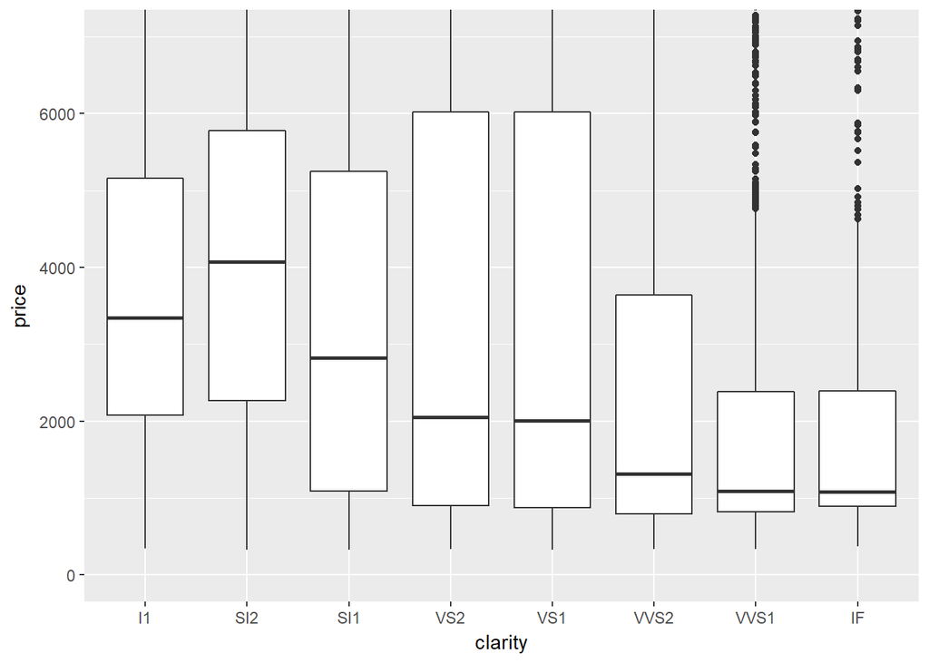

```r
qplot(x = clarity, y = price, data = diamonds,
      geom = 'boxplot') +
      coord_cartesian(ylim = c(0, 7000))
```

Para investigar mais afundo as descobertas da visualização anterior, criei dois dataframes com com dados da pior e melhor clareza.

```r
low <- subset(diamonds, clarity == 'I1')

high <- subset(diamonds, clarity == 'IF')
```

Visualizando os dados do preço por quilate do diamante de menor clareza.

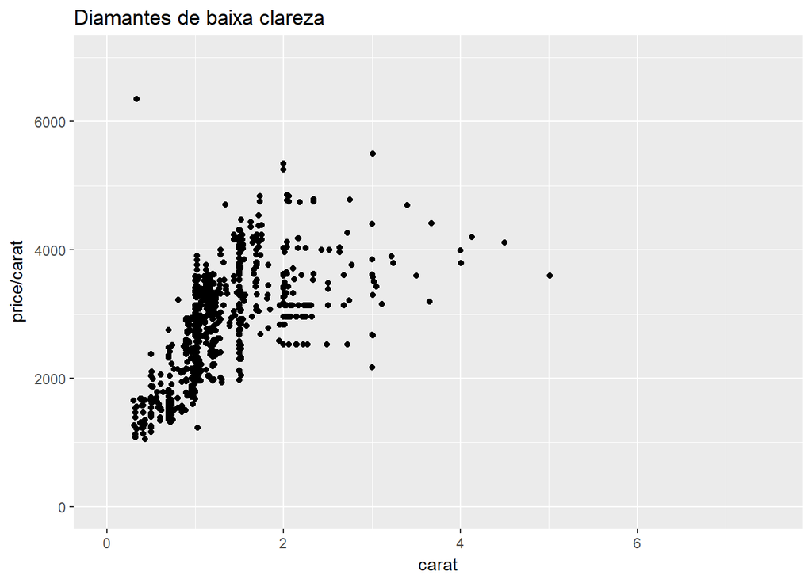

```r
qplot(x = carat, y = price/carat, data = low) +
  scale_x_continuous(lim=c(0,7.5)) +
  scale_y_continuous(lim=c(0,7000)) +
  labs(title = "Diamantes de baixa clareza")
```

Visualizando os dados do preço por quilate do diamante de maior clareza, percebemos que as pedras dos diamantes de maior clareza são bem menores e a faixa de preço é bem maior.

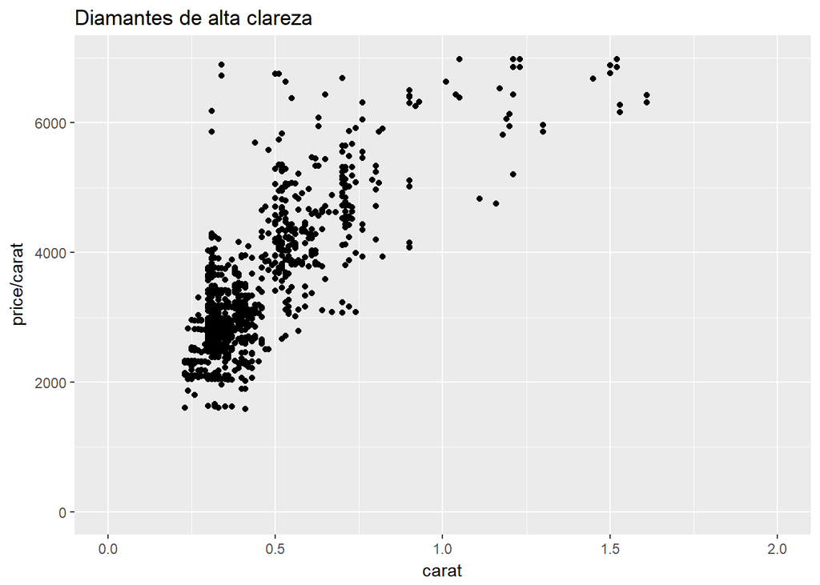

```r
qplot(x = carat, y = price/carat, data = high) +
  scale_x_continuous(lim=c(0, 2)) +
  scale_y_continuous(lim=c(0,7000)) +
  labs(title = "Diamantes de alta clareza")
```

```r
by(diamonds$price, diamonds$clarity, summary)
```

```
## diamonds$clarity: I1
##    Min. 1st Qu.  Median    Mean 3rd Qu.    Max.
##     345    2080    3344    3924    5161   18531
## --------------------------------------------------------
## diamonds$clarity: SI2
##    Min. 1st Qu.  Median    Mean 3rd Qu.    Max.
##     326    2264    4072    5063    5777   18804
## --------------------------------------------------------
## diamonds$clarity: SI1
##    Min. 1st Qu.  Median    Mean 3rd Qu.    Max.
##     326    1089    2822    3996    5250   18818
## --------------------------------------------------------
## diamonds$clarity: VS2
##    Min. 1st Qu.  Median    Mean 3rd Qu.    Max.
##     334     900    2054    3925    6024   18823
## --------------------------------------------------------
## diamonds$clarity: VS1
##    Min. 1st Qu.  Median    Mean 3rd Qu.    Max.
##     327     876    2005    3839    6023   18795
## --------------------------------------------------------
## diamonds$clarity: VVS2
##    Min. 1st Qu.  Median    Mean 3rd Qu.    Max.
##   336.0   794.2  1311.0  3283.7  3638.2 18768.0
## --------------------------------------------------------
## diamonds$clarity: VVS1
##    Min. 1st Qu.  Median    Mean 3rd Qu.    Max.
##     336     816    1093    2523    2379   18777
## --------------------------------------------------------
## diamonds$clarity: IF
##    Min. 1st Qu.  Median    Mean 3rd Qu.    Max.
##     369     895    1080    2865    2388   18806
```

Definindo os subconjuntos das cores D e J

```r
diamD <- subset(diamonds, color == 'D')
diamJ <- subset(diamonds, color == 'J')
```

Estatísticas de preço dos diamantes de cor “D”

```r
summary(diamD$price)
```

```
##    Min. 1st Qu.  Median    Mean 3rd Qu.    Max.
##     357     911    1838    3170    4214   18693
```

Estatísticas de preço dos diamantes de cor “J”

```r
summary(diamJ$price)
```

```
##    Min. 1st Qu.  Median    Mean 3rd Qu.    Max.
##     335    1860    4234    5324    7695   18710
```

Descobrindo o intervalo interquartil IQR das cores D

```r
IQR(diamD$price)
```

```
## [1] 3302.5
```

Descobrindo o intervalo interquartil IQR das cores J

```r
IQR(diamJ$price)
```

```
## [1] 5834.5
```

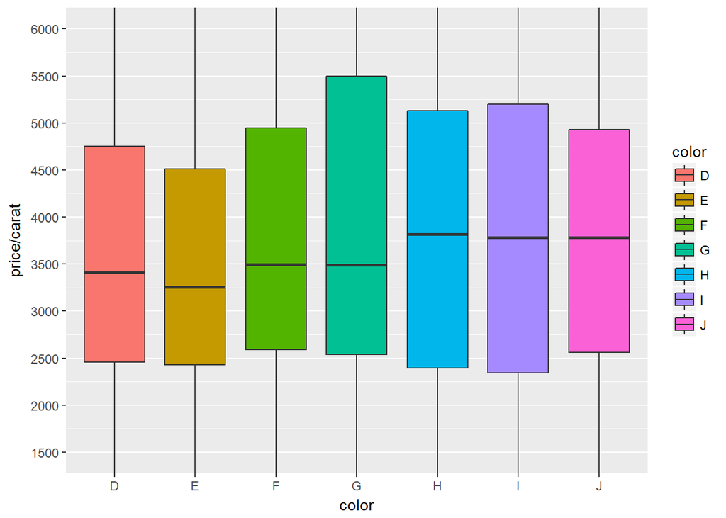

```r
qplot(x = color, y = price/carat, data = diamonds,
      geom = 'boxplot', fill = color) +
      coord_cartesian(ylim = c(1500, 6000)) +
      scale_y_continuous(breaks = seq(0, 6000, 500))
```

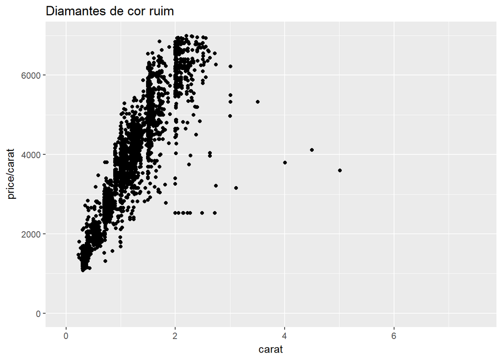

```r
qplot(x = carat, y = price/carat, data = diamJ) +
  scale_x_continuous(lim=c(0,7.5)) +
  scale_y_continuous(lim=c(0,7000)) +
  labs(title = "Diamantes de cor ruim")
```

Visualizando os diamantes de melhor cor

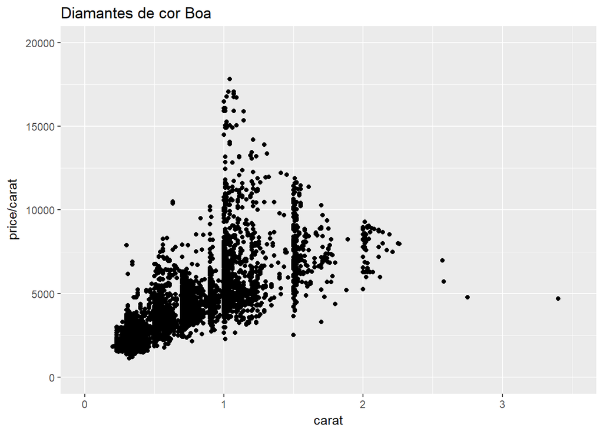

```r
qplot(x = carat, y = price/carat, data = diamD) +
  scale_x_continuous(lim=c(0,3.5)) +
  scale_y_continuous(lim=c(0,20000)) +
  labs(title = "Diamantes de cor Boa")
```

Obtendo os quilates que possui quantidade maior que 2 mil

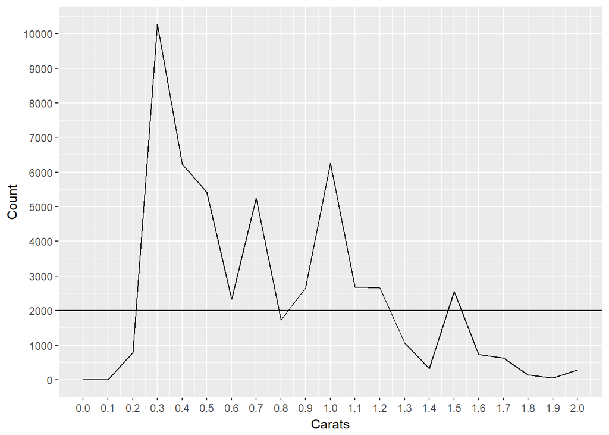

```r
qplot(x = diamonds$carat,
      data = diamonds,
      binwidth = 0.1,
      xlab = 'Carats',
      ylab = 'Count',
      geom = 'freqpoly') +
  scale_x_continuous(limits = c(0, 2), breaks = seq(0,2,0.1)) +
  scale_y_continuous(breaks = seq(0,12000,1000)) +
  geom_hline(yintercept = 2000)
```